# Módulo 1: Origens, Consolidação e Transição: a História da Biologia da Conservação

# QUINTA-FEIRA — TURNO DA TARDE

## Transição para a Ciência da Conservação

## Recapitulação da Manhã

- Humanos deixam de ser vistos apenas como ameaça externa
- Emergem como beneficiários e participantes dos sistemas ecológicos

## 25 Anos Depois de Soulé

- Kareiva & Marvier revisitam a pergunta fundadora do campo
- Contexto: um mundo já reconhecidamente dominado pela ação humana

## Kareiva & Marvier (2012): “What is Conservation Science?”

- Propõem uma ampliação do campo para uma “ciência da conservação”
- Interdisciplinaridade assumida como premissa, não como complemento

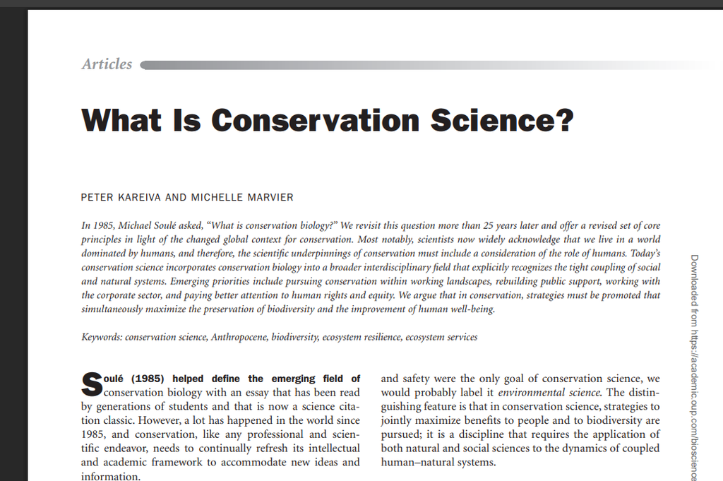

## Da Biologia à Ciência da Conservação: O que muda?

- Ponto de partida metodológico: acoplamento social-natural desde o início
- Não se trata apenas de “adicionar” ciências sociais à biologia

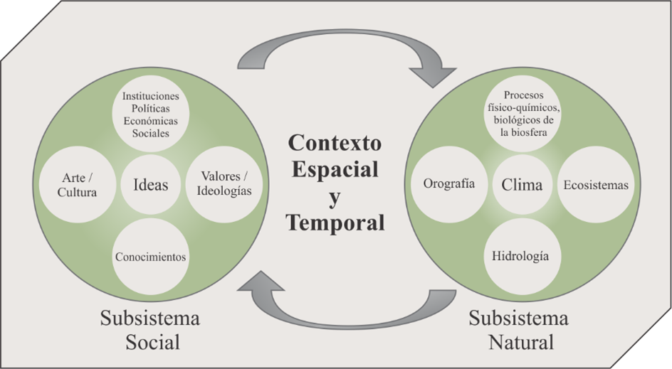

[Fonte:trinidad & Catilleros 2023](https://www.scielo.org.mx/scielo.php?script=sci_arttext&pid=S2007-74672022000200068)

## Nova prioridade: Paisagens produtivas

- Atuar também fora de áreas protegidas isoladas
- Reconhecer que a maior parte da biodiversidade vive em paisagens usadas por humanos

[figure not shown]

Cafezais no Peru

## Nova prioridade: Apoio público

- Reconstrução do apoio social e político às causas da conservação
- Ciência da conservação como projeto que depende de legitimidade pública

[figure not shown]

[Leia aqui a entrevista com o filósoifo Malcom Ferdinand](https://www.nexojornal.com.br/entrevista/2025/03/23/crise-climatica-e-racismo-entrevista-malcom-ferdinand-uma-ecologia-decolonial)

## Nova prioridade: Diálogo com o setor corporativo

- Reconhecimento do papel do setor privado nas decisões sobre uso da terra
- Proposta de engajamento em vez de oposição direta

[figure not shown]

[Como a USGA se vê na conservação?](https://www.usinaserragrande.com.br/sustentabilidade/acoes-ambientais)

## Nova Prioridade: Direitos humanos e equidade

- Atenção sistemática às dimensões de justiça nas políticas de conservação
- Equidade como critério explícito de avaliação das estratégias

[figure not shown]

## Duas correntes “tradicionais”

- Conservação tradicional: foco na proteção de áreas e espécies por seu valor intrínseco
- “New conservation”: foco no bem-estar humano como parte central da missão

## Onde fica a proteção de áreas naturais?

- Pergunta em aberto: esse novo paradigma abandona a proteção de áreas intocadas?
- Ou apenas amplia o repertório de estratégias disponíveis?

**Convergências entre os dois campos**

- Ambos compartilham o compromisso normativo com a proteção da biodiversidade
- Diferem principalmente no escopo metodológico e nas prioridades declaradas

## A BC como campo em redefinição permanente

- Não existe um ponto final de consolidação
- Cada geração de pesquisadores revisita e reformula a pergunta fundadora

**Implicações para a Prática Profissional**

- Profissionais da conservação hoje precisam transitar entre biologia, economia, política e ciências sociais
- Formação em pós-graduação reflete essa ampliação de escopo

## Atividade Final: Mapa Conceitual Comparativo

- Construir um mapa conceitual comparando *conservation biology* e *conservation science*
- Base: Meine et al. (2006); Dyke & Lamb (2020); Kareiva & Marvier (2012)

## Fechamento do Módulo 1

- Da crise ambiental dos anos 1960–70 à consolidação institucional dos anos 1980–90
- Das raízes filosóficas às tensões sobre valor intrínseco e instrumental
- Da exclusão humana à integração humano-natureza
- Da biologia da conservação à ciência da conservação interdisciplinar

## Prévia do Módulo 2

- Próximo tema: Desenvolvimento da Biologia da Conservação no Brasil